# Practicum 3

## Intro to Machine Learning/Data Mining | DA5030

## *Submitted by: Rajarshi Choudhury*

### Problem 1 : The practicum week is intended to deepen that material and foster discussion where you can learn from your peers and from problems encountered in solving the various questions. Therefore, interact on the discussion board, explore, investigate, share, and respond to each other.

#### 1a: (0 pts) Download the data set Bank Marketing Data Set. Note that the data file does not contain header names; you may wish to add those. The description of each column can be found in the data set explanation. Use the bank-full.csv data set but also download bank.csv and use that for testing and algorithm development.

```r
bank <- read.csv("bank-full.csv", sep = ";")
test <- read.csv("bank.csv", sep = ";")
```

Lets see the structure

```r
str(bank)
```

```
'data.frame':   45211 obs. of  17 variables:
 $ age      : int  58 44 33 47 33 35 28 42 58 43 ...
 $ job      : Factor w/ 12 levels "admin.","blue-collar",..: 5 10 3 2 12 5 5 3 6 10 ...
 $ marital  : Factor w/ 3 levels "divorced","married",..: 2 3 2 2 3 2 3 1 2 3 ...
 $ education: Factor w/ 4 levels "primary","secondary",..: 3 2 2 4 4 3 3 3 1 2 ...
 $ default  : Factor w/ 2 levels "no","yes": 1 1 1 1 1 1 1 2 1 1 ...
 $ balance  : int  2143 29 2 1506 1 231 447 2 121 593 ...
 $ housing  : Factor w/ 2 levels "no","yes": 2 2 2 2 1 2 2 2 2 2 ...
 $ loan     : Factor w/ 2 levels "no","yes": 1 1 2 1 1 1 2 1 1 1 ...
 $ contact  : Factor w/ 3 levels "cellular","telephone",..: 3 3 3 3 3 3 3 3 3 3 ...
 $ day      : int  5 5 5 5 5 5 5 5 5 5 ...
 $ month    : Factor w/ 12 levels "apr","aug","dec",..: 9 9 9 9 9 9 9 9 9 9 ...
 $ duration : int  261 151 76 92 198 139 217 380 50 55 ...
 $ campaign : int  1 1 1 1 1 1 1 1 1 1 ...
 $ pdays    : int  -1 -1 -1 -1 -1 -1 -1 -1 -1 -1 ...
 $ previous : int  0 0 0 0 0 0 0 0 0 0 ...
 $ poutcome : Factor w/ 4 levels "failure","other",..: 4 4 4 4 4 4 4 4 4 4 ...
 $ y        : Factor w/ 2 levels "no","yes": 1 1 1 1 1 1 1 1 1 1 ...
```

#### 1b: Explore the data set as you see fit and that allows you to get a sense of the data and get comfortable with it. Is there distributional skew in any of the features? Is there a need to apply a transform?

Let us see if there are any NA values

```r
anyNA(bank)
```

```
[1] FALSE
```

```r
anyNA(test)
```

```
[1] FALSE
```

So we see that there are no NA values. Because we will be using svm and neural net where svm is distance-based and has faster convergence on normalised data, and neural network works best when the values are between 0 and 1, we will normalise the data, irrespective of anything else. Also, we will be using dummy variables as we can’t use categorical values.

Lets first convert all columns to categorical values. Now for h categories, h-1 binary dummy feature codes are generated. Converting to dummy variable using dummyVars():

```r
#Creating dummy cariables for bank dataframe
library(lubridate)
library(caret)
dummybank <-dummyVars("~.",data=bank, fullRank = T) #creating dummy variables from factors in bank set.
bankdummy <- data.frame(predict(dummybank, newdata = bank))
#Let us now look at the new structure of the bank dataset:
str(bankdummy)
```

```
'data.frame':   45211 obs. of  43 variables:
 $ age                : num  58 44 33 47 33 35 28 42 58 43 ...
 $ job.blue.collar    : num  0 0 0 1 0 0 0 0 0 0 ...
 $ job.entrepreneur   : num  0 0 1 0 0 0 0 1 0 0 ...
 $ job.housemaid      : num  0 0 0 0 0 0 0 0 0 0 ...
 $ job.management     : num  1 0 0 0 0 1 1 0 0 0 ...
 $ job.retired        : num  0 0 0 0 0 0 0 0 1 0 ...
 $ job.self.employed  : num  0 0 0 0 0 0 0 0 0 0 ...
 $ job.services       : num  0 0 0 0 0 0 0 0 0 0 ...
 $ job.student        : num  0 0 0 0 0 0 0 0 0 0 ...
 $ job.technician     : num  0 1 0 0 0 0 0 0 0 1 ...
 $ job.unemployed     : num  0 0 0 0 0 0 0 0 0 0 ...
 $ job.unknown        : num  0 0 0 0 1 0 0 0 0 0 ...
 $ marital.married    : num  1 0 1 1 0 1 0 0 1 0 ...
 $ marital.single     : num  0 1 0 0 1 0 1 0 0 1 ...
```

[output cut: 29 more lines]

```r
dummytest <-dummyVars("~.",data=test, fullRank = T) #creating the dummy variables in test set.
testdummy <- data.frame(predict(dummytest, newdata = test))
#Let us now look at the new structure of the test dataset:
str(testdummy)
```

```
'data.frame':   4521 obs. of  43 variables:
 $ age                : num  30 33 35 30 59 35 36 39 41 43 ...
 $ job.blue.collar    : num  0 0 0 0 1 0 0 0 0 0 ...
 $ job.entrepreneur   : num  0 0 0 0 0 0 0 0 1 0 ...
 $ job.housemaid      : num  0 0 0 0 0 0 0 0 0 0 ...
 $ job.management     : num  0 0 1 1 0 1 0 0 0 0 ...
 $ job.retired        : num  0 0 0 0 0 0 0 0 0 0 ...
 $ job.self.employed  : num  0 0 0 0 0 0 1 0 0 0 ...
 $ job.services       : num  0 1 0 0 0 0 0 0 0 1 ...
 $ job.student        : num  0 0 0 0 0 0 0 0 0 0 ...
 $ job.technician     : num  0 0 0 0 0 0 0 1 0 0 ...
 $ job.unemployed     : num  1 0 0 0 0 0 0 0 0 0 ...
 $ job.unknown        : num  0 0 0 0 0 0 0 0 0 0 ...
 $ marital.married    : num  1 1 0 1 1 0 1 1 1 1 ...
 $ marital.single     : num  0 0 1 0 0 1 0 0 0 0 ...
```

[output cut: 29 more lines]

We see new dataframes where all the data are now numeric. Also the column names have been changed; for example, y changed to y.yes.

We see that most of the column names have changed. Now we will normalize all the data frame except y.yes from bankdummy df. Here 0 is “no” and 1 is “yes” Let us now normalize all the data. We will use min-max normalisation.

```r
normalize <- function(x) { #developing min-max normalization function
return((x - min(x)) / (max(x) - min(x)))
}
#normalizing bank data:
banknorm <- as.data.frame(lapply(bankdummy, normalize)) #using lapply to normalize every column
#To confirm all the data have worked properly:
str(banknorm$age)
```

```
 num [1:45211] 0.519 0.338 0.195 0.377 0.195 ...
```

```r
#normalizing test data
testnorm <- as.data.frame(lapply(testdummy, normalize)) #using lapply to normalize every column
#To confirm all the data have worked properly:
str(testnorm$age)
```

```
 num [1:4521] 0.162 0.206 0.235 0.162 0.588 ...
```

We see that in both the datasets, all the values have been normalized.

#### 1c: (20 pts) Build a classification model using a support vector machine that predicts if a bank customer will open a term deposit account.

So we will be developing support vector machine to predict y.yes we will be using the svm() function from library e1071(). Also, we will be using the column y.yes as factors for the output to be of the shape of 0 or 1.

```r
library(e1071)
model_svm <- svm(as.factor(y.yes) ~ ., data=banknorm)
summary(model_svm)
```

```
Call:
svm(formula = as.factor(y.yes) ~ ., data = banknorm)


Parameters:
   SVM-Type:  C-classification
 SVM-Kernel:  radial
       cost:  1
      gamma:  0.02380952381

Number of Support Vectors:  10413

 ( 5597 4816 )


Number of Classes:  2

Levels:
 0 1
```

Let us find its accuracy:

```r
pred_svm <- predict(model_svm, testnorm)
table(pred_svm,testnorm$y)
```

```
pred_svm    0    1
       0 3869  310
       1  131  211
```

We see that accuracy is (4080/4521)*100 = 90.245%

For increasing accuracy, let us calculate the cost and gamma function. The below code distinguishes how to find the cost and gamma function, use it in model development, and finding the model performance.

However the code is *intentionally commented* as running this code should be done with gpu for decreasing run-time complexity.

```r
##Finding cost and gamma function:
#svm_tune <- tune(svm, as.factor(y.yes) ~ ., data = banknorm, kernel="radial", ranges=list(cost=10^(-1:2), gamma=c(.5,1,2)))
#print(svm_tune)
##Using the cost and gamma function in model development:
#modelsvm_after_tune <- svm(Pred ~ ., data=train_rf, kernel="radial", cost=0.1, gamma=0.5)
#summary(modelsvm_after_tune)
##Finding accuracy of the model:
#pred_svm <- predict(modelsvm_after_tune, test_rf)
#table(pred_svm,test_rf$Pred)
```

#### 1d: Build another classification model using a neural network that also predicts if a bank customer will open a term deposit account.

So now we need to use neural network. All the data has already been converted to numeric and normalized. So we will directly put the values in neural network:

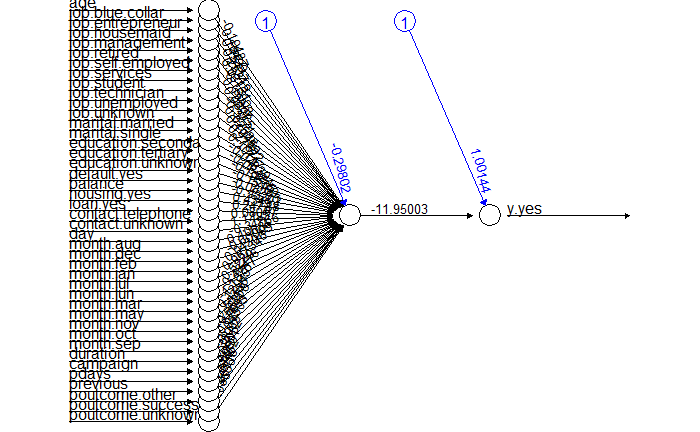

```r
library(neuralnet)
n <- names(banknorm)
f <- as.formula(paste("y.yes ~", paste(n[!n %in% "y.yes"], collapse = " + "))) #neuralnet() does not support the ~. notation. As a workaround, we use the as.formula and pass it to neuralnet()
set.seed(12345) #since neuralnet has randomized initialization, we set the seed.
model_nn <- neuralnet(f,data=banknorm,linear.output=F)
plot(model_nn)
```

Evaluating performance of neural network:

```r
model_results <- compute(model_nn, testnorm[-43]) #we use compute() as predict() cannot be used here.
pa <- model_results$net.result
pred_nn <- ifelse(pa > 0.5,1,0) #converting all values above 0.5 to 1, else to 0.
tab1 <- table(pred_nn,testnorm$y.yes)
tab1
```

```
pred_nn    0    1
      0 3532  150
      1  468  371
```

So we see the accuracy with a single neural network is (3903/4521)*100 = 86.33%

Improving model performance: We can improve the model performance by increasing hidden layers. However, since the code will require significant run-time complexity, it is *intentionally commented*. However the code can be run faster if someone has gpu access.

```r
#f <- as.formula(paste("y.yes ~", paste(n[!n %in% "y.yes"], collapse = " + ")))
#model_nn <- neuralnet(f,data=banknorm,hidden = c(35,20,15,5),linear.output=F)
#plot(model_nn)
```

#### 1e: Compare the accuracy of the two models based on absolute accuracy and AUC.

Let us now find absolute accuracy and AUC of the two models.The absolute accuracy was already found out with the model development, although we will be doing it again.

Support Vector Machine:

Absolute Accuracy:

```r
table(pred_svm,testnorm$y)
```

```
pred_svm    0    1
       0 3869  310
       1  131  211
```

We see that our absolute accuracy is : (4080/4521)*100 = 90.245%

AUC:

```r
library(pROC)
roc_svm <- roc(pred_svm,testnorm$y)
auc(roc_svm)
```

```
Area under the curve: 0.7713893
```

We see that AUC is: 0.7713893

Neural Network:

Absolute Accuracy:

```r
tab1 <- table(pred_nn,testnorm$y.yes)
tab1
```

```
pred_nn    0    1
      0 3532  150
      1  468  371
```

We see that our absolute accuracy is : (3903/4521)*100 = 86.33%

AUC:

```r
roc_nn <- roc(pred_nn,testnorm$y.yes)
```

```
Deprecated use a matrix as response. Unexpected results may be produced, please pass a vector or factor.
```

```r
auc(roc_nn)
```

```
Area under the curve: 0.7007272
```

We see that AUC is: 0.7007272. (It is to be noted here that sometimes a warning may be displayed intermittently, however, it has no effect on AUC calculation here and the code works fine)

### Problem 2:

#### 2.1: Download the data set Plant Disease Data Set. Note that the data file does not contain header names; you may wish to add those. The description of each column can be found in the data set explanation. This assignment must be completed within an R Markdown Notebook.

Let us first read the data:

```r
library(arules)
plants <- read.transactions("https://archive.ics.uci.edu/ml/machine-learning-databases/plants/plants.data", format = "basket", sep = ",", cols = 1)
summary(plants)
```

```
transactions as itemMatrix in sparse format with
 34781 rows (elements/itemsets/transactions) and
 70 columns (items) and a density of 0.1240882748

most frequent items:
     ca      tx      or      az      fl (Other)
  11676    8483    7028    6778    6621  261528

element (itemset/transaction) length distribution:
sizes
    1     2     3     4     5     6     7     8     9    10    11    12    13    14    15    16    17    18    19    20    21    22    23
11566  4874  2954  2107  1366  1094   859   744   655   562   503   421   421   333   322   284   252   241   249   207   200   212   198
   24    25    26    27    28    29    30    31    32    33    34    35    36    37    38    39    40    41    42    43    44    45    46
  195   155   152   190   179   159   146   140   146   148   147   119   123   110   124   118   114    83    85   102    90    90    75
   47    48    49    50    51    52    53    54    55    56    57    58    59    60    61    62    63    64    65    66    67    68    69
   64    89    63    60    64    68    56    54    51    59    47    45    39    59    52    43    39    43    47    60    35    26     4

     Min.   1st Qu.    Median      Mean   3rd Qu.      Max.
 1.000000  1.000000  3.000000  8.686179  9.000000 69.000000

includes extended item information - examples:
  labels
1     ab
2     ak
3     al

includes extended transaction information - examples:
         transactionID
1               abelia
2 abelia x grandiflora
3          abelmoschus
```

We see we have 34781 rows and 70 columns. We can have certain observations like the most frequent items, element length distribution, etc.

Let’s check the data:

```r
inspect(plants[1:5])
```

```
    items                                          transactionID
[1] {fl,nc}                                        abelia
[2] {fl,nc}                                        abelia x grandiflora
[3] {ct,dc,fl,hi,il,ky,la,md,mi,ms,nc,pr,sc,va,vi} abelmoschus
[4] {ct,dc,fl,il,ky,la,md,mi,ms,nc,pr,sc,va,vi}    abelmoschus esculentus
[5] {hi,pr}                                        abelmoschus moschatus
```

#### 2b: Are there clusters in the data? Can plants be segmented into groups? Build a k-means clustering model to investigate. (using a package of your choice.)

We will first form the sparse matrix, and then preserve the matrix, before the kmeans is conserved.

```r
# Forming sparse matrix for the transaction data
plantmatrix <- as.data.frame(as(plants, "matrix"))
plantmatrix[,1:70] <- lapply(plantmatrix[,1:70], as.integer)
# Making new variable for preserving original data
plantmatrix2 <- plantmatrix
str(plantmatrix2)
```

```
'data.frame':   34781 obs. of  70 variables:
 $ ab    : int  0 0 0 0 0 1 0 0 1 1 ...
 $ ak    : int  0 0 0 0 0 1 0 1 0 0 ...
 $ al    : int  0 0 0 0 0 0 0 0 0 0 ...
 $ ar    : int  0 0 0 0 0 0 0 0 0 0 ...
 $ az    : int  0 0 0 0 0 1 0 0 0 0 ...
 $ bc    : int  0 0 0 0 0 1 0 1 0 0 ...
 $ ca    : int  0 0 0 0 0 1 0 1 0 0 ...
 $ co    : int  0 0 0 0 0 1 0 0 0 0 ...
 $ ct    : int  0 0 1 1 0 1 0 0 1 1 ...
 $ dc    : int  0 0 1 1 0 0 0 0 0 0 ...
 $ de    : int  0 0 0 0 0 0 0 0 0 0 ...
 $ dengl : int  0 0 0 0 0 0 0 0 0 0 ...
 $ fl    : int  1 1 1 1 0 0 0 0 0 0 ...
 $ fraspm: int  0 0 0 0 0 1 0 0 1 1 ...
```

[output cut: 56 more lines]

Developing the kmeans algorithm:

```r
library(lattice)
library(caret)
# PCA analysis using BoxCox
trans <- preProcess(plantmatrix2[,1:70], method = c("BoxCox","center","scale","pca"))
pca<- predict(trans,plantmatrix2[,1:70])
```

```
is.na() applied to non-(list or vector) of type 'NULL'
```

```r
head(pca)
```

|  | PC1 | PC2 | PC3 | PC4 | PC5 | PC6 | PC7 | PC8 | PC9 | PC10 | PC11 | PC12 | PC13 | PC14 | PC15 | PC16 | PC17 | PC18 | PC19 | PC20 | PC21 | PC22 | PC23 | PC24 | PC25 | PC26 | PC27 | PC28 | PC29 | … |
| --- | --- | --- | --- | --- | --- | --- | --- | --- | --- | --- | --- | --- | --- | --- | --- | --- | --- | --- | --- | --- | --- | --- | --- | --- | --- | --- | --- | --- | --- | --- |
| abelia | -2.363319646 | -0.9964322066 | -0.6384921357 | -0.5616724761 | -0.08342610768 | -0.04771027814 | 0.1812079897 | -0.4734805052 | 1.13918093423 | -0.09890436197 | -0.2680605105 | 0.3522824209 | 0.02850499843 | 0.06003032608 | -0.3020564536 | -0.1700643177 | -0.68075666817 | 0.4779728969 | 0.3361086642 | -0.19776469122 | -0.52235717615 | -0.10309861876 | 0.1641071395 | -1.10010969538 | -0.12657472843 | 0.7877640795 | 0.249371959644 | -0.4453595145 | -0.2485916062 | … |
| abelia x grandiflora | -2.363319646 | -0.9964322066 | -0.6384921357 | -0.5616724761 | -0.08342610768 | -0.04771027814 | 0.1812079897 | -0.4734805052 | 1.13918093423 | -0.09890436197 | -0.2680605105 | 0.3522824209 | 0.02850499843 | 0.06003032608 | -0.3020564536 | -0.1700643177 | -0.68075666817 | 0.4779728969 | 0.3361086642 | -0.19776469122 | -0.52235717615 | -0.10309861876 | 0.1641071395 | -1.10010969538 | -0.12657472843 | 0.7877640795 | 0.249371959644 | -0.4453595145 | -0.2485916062 | … |
| abelmoschus | 1.743408560 | -4.5668128668 | -0.2124727905 | -2.5304105060 | -0.40474839134 | 3.18979845672 | 3.3228612216 | 1.7107868873 | -0.40041330544 | -1.18117627093 | 1.0131712843 | 0.9954395677 | -0.05945454890 | 0.31224964443 | 0.3719322937 | -0.4146235327 | 0.22494397200 | 0.2555789714 | 1.0074286556 | 0.04464414342 | 0.64650890702 | -0.46885479365 | -0.6277805675 | 0.13375265309 | -0.04975871951 | -0.5564031527 | -0.433855607011 | 0.3887174509 | -0.2903801838 | … |
| abelmoschus esculentus | 1.698307706 | -4.4875365014 | -0.2107628038 | -2.2816548803 | -0.54982897024 | 2.36926272084 | 2.8214133576 | 1.7126086226 | 0.07336371751 | -0.87334174376 | -1.8333506535 | 0.4020818249 | 0.32396121817 | -0.07181356342 | 0.3223300161 | -0.3212090993 | 0.05485747231 | 0.4225648642 | 0.9762965157 | -0.11712979821 | 0.61421690085 | -0.34662190532 | -0.7204163283 | 0.04085884244 | -0.10876093120 | -0.6931402832 | -0.403504884675 | 0.4126448169 | -0.3265784339 | … |
| abelmoschus moschatus | -2.857036244 | -0.4380101430 | -0.8550407218 | -0.2236621275 | 0.94851734762 | 1.57864517418 | 1.4489453945 | 0.2482808312 | -0.54402146110 | -0.69422134709 | 2.0232595264 | 0.3557644340 | -0.63448310174 | 0.14025058813 | 0.2306580682 | 0.1632808983 | 0.09704898568 | 0.0747224989 | -0.5843541235 | -0.21698805472 | -0.31044611027 | 0.09546000206 | 0.3711566324 | 1.62622940017 | 0.36947814441 | 0.7533769856 | 0.004712676264 | -0.2658288756 | 0.1072472362 | … |
| abies | 14.676336860 | 9.8601766709 | -4.7096664851 | -2.0542527007 | -2.55819909983 | 0.70253387720 | -2.1699911214 | 1.7946008003 | 0.41747867414 | -0.97368858200 | -1.1724034234 | 0.4516632144 | 0.41839712169 | 2.56974297362 | 1.5538317089 | -0.2583636906 | 0.33672106175 | -1.3835668719 | 0.4513055522 | 1.76187249474 | 0.02816118878 | -1.56231350921 | 3.3700450353 | -0.44126816182 | 0.34573648560 | 1.7789431341 | -1.970888497001 | -0.3691902665 | 1.0641815502 | … |

```r
# Model
# Selecting number of clusters = 7
set.seed(2345) #kmeans algorithm utilizes random starting points
plantclusters <- kmeans(plantmatrix2,7)
plantclusters$size
```

```
[1] 20957  2651  1983  2685  1382  1366  3757
```

We see that the data has been divided into 7 clusters, although the majority of the data lies in cluster 1. Smallest cluster has 1366 rows, and the largest cluster has 20957 rows.

```r
# Examining the coordinates of clusters
plantclusters$centers
```

```
              ab             ak             al            ar            az             bc           ca            co             ct
1 0.014792193539 0.045760366465 0.019086701341 0.01708259770 0.04828935439 0.048575654912 0.3114472491 0.01975473589 0.012406355872
2 0.547717842324 0.299132402867 0.006412674462 0.03470388533 0.42323651452 0.662391550358 0.6721991701 0.68351565447 0.020369671822
3 0.035300050429 0.014120020171 0.903681290973 0.88502269289 0.14523449319 0.093797276853 0.1956631367 0.13565305093 0.768028240040
4 0.002607076350 0.002234636872 0.875605214153 0.43351955307 0.09944134078 0.018249534451 0.1344506518 0.03054003724 0.068156424581
5 0.807525325615 0.580318379161 0.700434153401 0.74312590449 0.79667149059 0.909551374819 0.8914616498 0.93487698987 0.943560057887
6 0.318448023426 0.273792093704 0.093704245974 0.05197657394 0.04392386530 0.434846266471 0.2101024890 0.17935578331 0.774524158126
7 0.004791056694 0.001863188714 0.012243811552 0.03806228374 0.77934522225 0.003992547245 0.2925206282 0.35959542188 0.002395528347
              dc             de          dengl             fl          fraspm             ga              gl            hi            ia
1 0.004628525075 0.004867108842 0.001002051820 0.107935296082 0.0030061554612 0.024430977716 0.0127403731450 0.12740373145 0.00782554755
2 0.006789890607 0.007167106752 0.007544322897 0.006035458318 0.0128253489249 0.009053187476 0.0607317993210 0.01282534892 0.10298000754
3 0.736258194655 0.784669692385 0.000000000000 0.643973777105 0.0484114977307 0.913262733232 0.0030257186082 0.09026727181 0.64649520928
4 0.094599627561 0.165363128492 0.000000000000 0.785474860335 0.0003724394786 0.884543761639 0.0003724394786 0.12737430168 0.04096834264
5 0.722141823444 0.793053545586 0.208393632417 0.573806078148 0.4175108538350 0.724312590449 0.0513748191027 0.34008683068 0.94283646889
6 0.180087847731 0.297950219619 0.109809663250 0.038799414348 0.3213762811127 0.139092240117 0.0402635431918 0.02855051245 0.33235724744
```

[output cut: 49 more lines]

The rows of the output given by 1 to 7 refer to the seven clusters, the numbers across each row indicate the cluster’s average value for the interest listed at the top of the column. By analysing whether the clusters fall above or below the mean for each interest category, we can begin to notice patterns that distinguish the clusters from each other.

#### 1c: (+10 pts) Visualize the clusters.

Lets try to visualize the cluster spread:

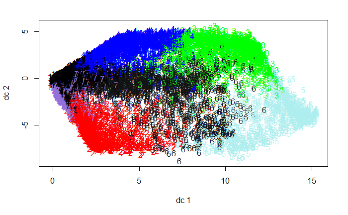

```r
library(klaR)
library(MASS)
library(fpc)
plotcluster(plantmatrix,plantclusters$cluster)
```

`We can see how the clusters are spread in the original data. We can also see how clusters also seem to be intertwined. The density of the clusters can also be seen from the plot above.

Sources: Machine Learning with R - 2nd edition